# ESM 204: Practice Final

Note: The actual final will be somewhat shorter than this practice exam.

1. Community A is composed of residents that have historically been disadvantaged. Community B is composed of wealthy residents. Polluters in A have pollution demand: P = 20 − Q_A, where Q_A is pollution in A. Polluters in B have pollution demand: P = 20 − 2*Q_B.
1. Without any regulation, how much pollution do you expect in each community? Is there an Environmental Justice problem (i.e. is there more pollution in the disadvantaged community)?

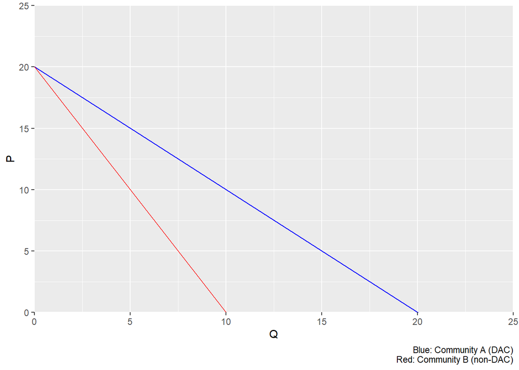

```r
ggplot() +
  # Community A
  geom_abline(aes(intercept = 20,
                  slope = -1),
              color = "blue") +
  # Community B
  geom_abline(aes(intercept = 20,
                  slope = -2),
              color = "red") +
  labs(x = "Q",
       y = "P",
       caption = "Blue: Community A (DAC)\nRed: Community B (non-DAC)") +
  scale_x_continuous(limits = c(0, 25),
                     expand = c(0,0)) +
  scale_y_continuous(limits = c(0, 25),
                     expand = c(0,0))
```

```r
# Level of pollution
## Community A

# P = 20 - Q_A
# Q_A = 20 - P

P <- 0
Q_A <- 20 - P

# 20

## Community B
# P = 20 - 2 * Q_B
# Q_B = (20 - P) / 2

Q_B <- (20 - P) / 2
# 10

# EJ Gap

EJ <- Q_A - Q_B
```

EJ Gap = Q_A - Q_B = 20 - 10 = 10

2. Suppose a standard is set where pollution cannot exceed Q¯ = 6 in any community. What is the cost to firms in A of achieving this standard? What is the cost to firms in B? What is the total cost?

```r
new_level <- 6

# Cost to A
# Reduction from 20 to 6

Q_A_b <- 6

P_A_b <- 20 - Q_A_b

cost_A <- ((Q_A - new_level) * P_A_b) / 2


# Cost to B
# Reduction from 10 to 6

Q_B_b <- 6

P_B_b <- 20 - 2 * Q_A_b

cost_B <- ((Q_B - new_level) * P_B_b) / 2

# Total Cost

tot_cost <- cost_A + cost_B
```

Cost to A: 98

Cost to B: 16

Total Cost: 114

3. Suppose firms in A are allowed to pollute 6 and firms in B are allowed to pollute 6, and that they are allowed to trade pollution rights. What would be the trading price of pollution permits? Which firm would buy and which firm would sell, and how much?

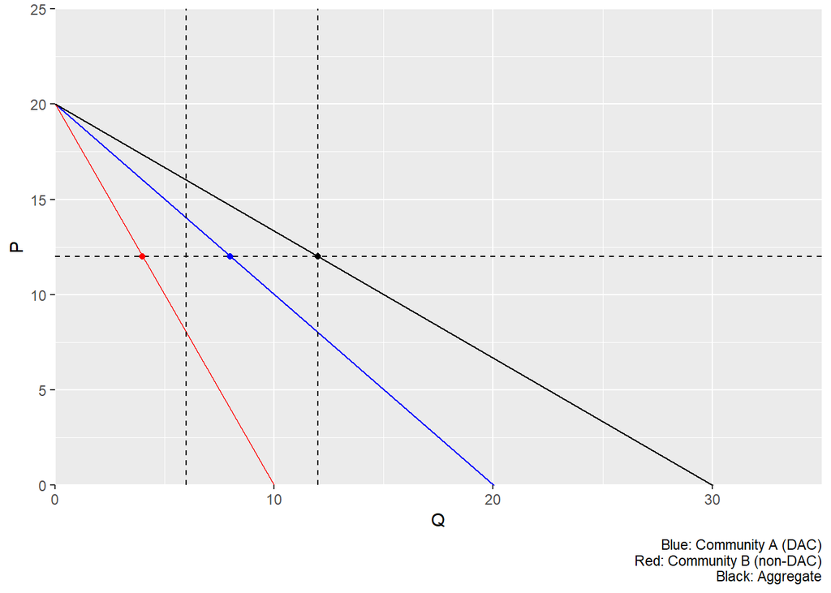

```r
Q <- 6 + 6

agg_p <- 20 - (2 * Q / 3)

Q_A_lim <- 20 - agg_p

Q_B_lim <- (20 - agg_p) / 2


ggplot() +
  # Community A
  geom_abline(aes(intercept = 20,
                  slope = -1),
              color = "blue") +
  # Community B
  geom_abline(aes(intercept = 20,
                  slope = -2),
              color = "red") +
  # Aggregate
  geom_abline(aes(intercept = 20,
                  slope = -2/3)) +
  # Vertical
  geom_vline(aes(xintercept = Q),
             linetype = "dashed") +
  geom_vline(aes(xintercept = Q/2),
             linetype = "dashed") +
  # Horizontal
  geom_hline(aes(yintercept = agg_p),
             linetype = "dashed") +
  # Points
  geom_point(aes(x = Q,
                 y = agg_p)) +
  geom_point(aes(x = Q_A_lim,
                 y = agg_p),
             color = "blue") +
  geom_point(aes(x = Q_B_lim,
                 y = agg_p),
             color = "red") +
  labs(x = "Q",
       y = "P",
       caption = "Blue: Community A (DAC)\nRed: Community B (non-DAC)\nBlack: Aggregate") +
  scale_x_continuous(limits = c(0, 35),
                     expand = c(0,0)) +
  scale_y_continuous(limits = c(0, 25),
                     expand = c(0,0))
```

Trading price of permits: $12

Community A would demand 8 units

Community B would demand 4 units

Therefore, Community B would sell up to 2 units to Community A, which would be willing to buy up to 2 units

4. What are the EJ implications of each of the following policies:
1. No regulation

EJ Gap = Q_A - Q_B = 20 - 10 = 10

2. Standard of 6 everywhere, and

No EJ gap

3. Cap and trade (with cap of 6 in A and cap of 6 in B, and subsequent trading)

EJ Gap = Q_A - Q_B = 8 - 4 = 4

2. The demand for river rafting trips down the Colorado River is given by: P = 500 − Q/2 (where P is $/trip and Q is number of trips each summer). The cost of providing each trip (paying the guide, raft, food, etc.) is $100.
1. If there is a free market for rafting trips, how many trips would you expect? What would be the price of a trip?

```r
C <- 100

P <- C

Q <- (500 - P) * 2
```

800 trips at $100/trip

2. Suppose that each trip also imposes some external costs, through congestion, litter, wildlife disturbance, etc. The Qth trip imposes an external cost of 3Q/2. Draw the demand, marginal private cost, and marginal external cost curves.

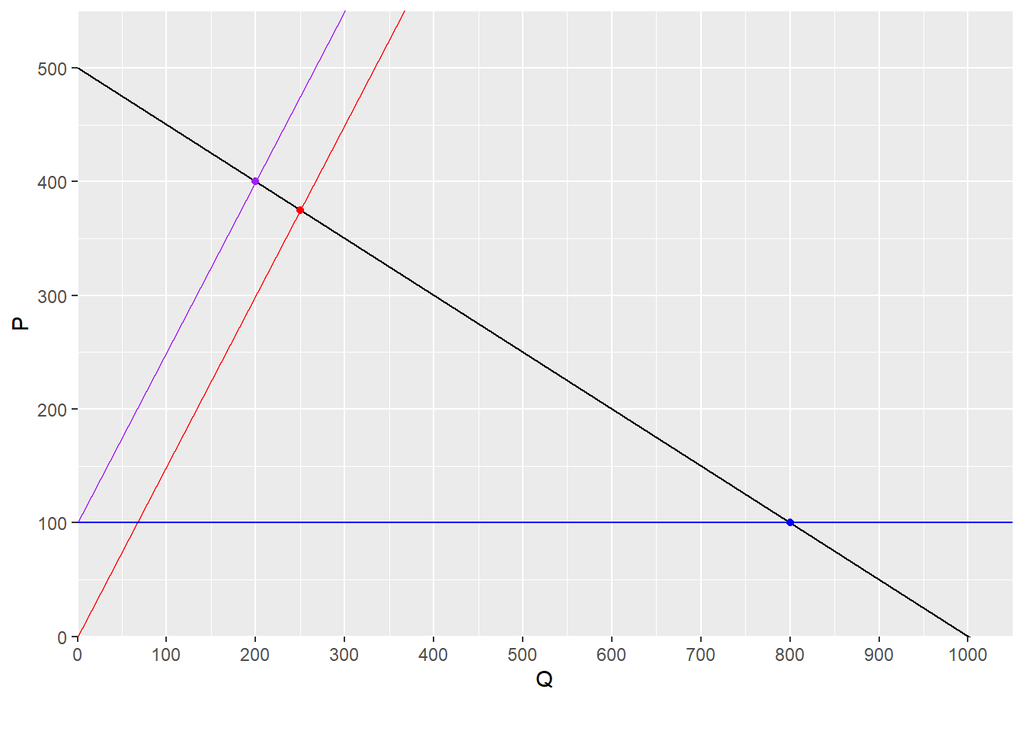

```r
ggplot() +
  # Demand
  geom_abline(aes(intercept = 500,
                  slope = -0.5),
              color = "black") +
  # MEC
  geom_abline(aes(intercept = 0,
                  slope = 1.5),
              color = "red") +
  # MSC
  geom_abline(aes(intercept = C,
                  slope = 1.5),
              color = "purple") +
  # Horizontal
  geom_hline(aes(yintercept = C),
             color = "blue") +
  labs(x = "Q",
       y = "P",
       caption = "") +
  # Points
  ## Demand & Cost
  geom_point(aes(x = Q,
                 y = P),
             color = "blue") +
  ## Optimal (Demand & MSC)
  geom_point(aes(x = 200,
                 y = 500 - 200/2),
             color = "purple") +
  ## Demand & MEC
  geom_point(aes(x = 250,
                 y = 500 - 250/2),
             color = "red") +
  scale_x_continuous(limits = c(0, 1050),
                     expand = c(0,0),
                     breaks = seq(0, 1000, by = 100)) +
  scale_y_continuous(limits = c(0, 550),
                     expand = c(0,0))
```

3. Taking all private and external costs into account, what is the socially optimal number of rafting trips on the Colorado River?

200 trips

```r
utility <- function(x){
  u = x ^ 1.3
  return(u)
}
```

1. Is Felicity Risk Averse or Risk Loving?

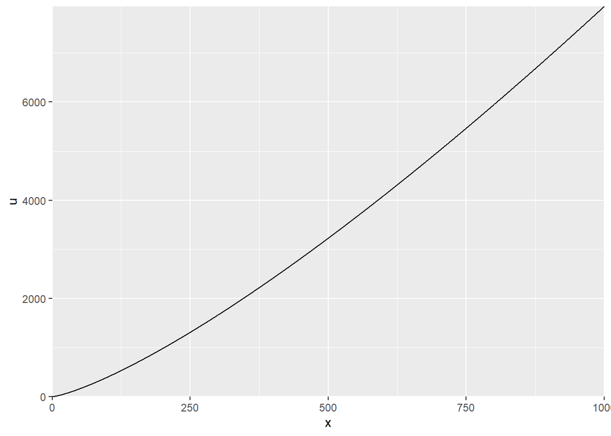

```r
felicity <- data.frame(x = seq(0, 1000, by = 0.1)) %>%
  mutate(u = utility(x))

ggplot() +
  geom_line(data = felicity,
            aes(x = x,
                y = u)) +
  scale_x_continuous(expand = c(0,0)) +
  scale_y_continuous(expand = c(0,0))
```

Felicity is risk loving.

2. Felicity is throwing darts at the county fair and has already popped the requisite 3 balloons to win a prize. She faces the following options:

• Option A: Stop playing now, and receive a payoff of $10, or

• Option B: Throw one more dart with the following payoff: - $100 If she pops a balloon and – $0 if she does not pop a balloon.

```r
payoff_A <- 10

utility_A <- utility(payoff_A)


p_B_pop <-  0.1
payoff_B_pop <-  100

p_B_no_pop <- 1 - p_B_pop
payoff_B_no_pop <-  0

utility_B <- utility(p_B_pop * payoff_B_pop + p_B_no_pop * payoff_B_no_pop)
```

If Felicity believes the probability she will pop a balloon is p = 0.1, will she choose Option A or Option B?

Utility of Option A: 19.95

Utility of Option B: 19.95

Felicity is indifferent. Since she is risk loving, she will choose the gamble of Option B.

3. In a sudden boost of confidence, Felicity now thinks p = 0.2. Which option does she choose?

```r
p_B_pop_2 <-  0.2
payoff_B_pop_2 <-  100

p_B_no_pop_2 <- 1 - p_B_pop
payoff_B_no_pop_2 <-  0

utility_B_2 <- utility(p_B_pop_2 * payoff_B_pop_2 + p_B_no_pop_2 * payoff_B_no_pop_2)
```

Utility of Option A: 19.95

Utility of Option B: 49.13

Felicity will choose Option B.

4. Dam removal is extremely costly, but can deliver long-term ecological benefits. The cost of removing the Big River dam is $100 million, which has to be paid immediately. Starting one year from now, there are other remediation costs of $5 million per year for 5 years. The benefit of dam removal is $10 million per year, starting in year 20. This benefit occurs every year and goes on forever. (Hint: Remember that for any reasonable positive value of r, you only need to go out 100 years or so before the present value becomes very small. so if you do this numerically, you only need to run it out for about 100 years to decide which policy is better. )

```r
cost_imm <- 100

cost_int <- 5

int_yr <- 5

ben <- 10

ben_start <- 20

len <- 100
```

1. If the discount rate is r = 0, what is the present value of costs? What is the present value of benefits? Do the benefits of dam removal outweigh the costs?

```r
r <- 0

q4_a <- data.frame(year = seq(0, len, by = 1),
                   cost = c(cost_imm,
                            rep(cost_int, int_yr),
                            rep(0, len - int_yr)),
                   benefit = c(rep(0, ben_start),
                               rep(ben, len - ben_start + 1))) %>%
  mutate(PV_C = cost / ((1 + r) ^ year),
         PV_B = benefit / ((1 + r) ^ year))

PV_C_0 <- sum(q4_a$PV_C)
PV_B_0 <- sum(q4_a$PV_B)
```

Present Value at r = 0 after 100 years

Costs: $125 million

Benefits: $810 million

The benefits outweigh the costs.

2. If the discount rate is r = .05, do the benefits outweigh the costs? If the discount rate is r = .01, do the benefits outweigh the cost?

```r
r <- 0.05

q4_b1 <- data.frame(year = seq(0, len, by = 1),
                   cost = c(cost_imm,
                            rep(cost_int, int_yr),
                            rep(0, len - int_yr)),
                   benefit = c(rep(0, ben_start),
                               rep(ben, len - ben_start + 1))) %>%
  mutate(PV_C = cost / ((1 + r) ^ year),
         PV_B = benefit / ((1 + r) ^ year))

PV_C_05 <- sum(q4_b1$PV_C)
PV_B_05 <- sum(q4_b1$PV_B)
```

Present Value at r = 0.05 after 100 years

Costs: $121.65 million

Benefits: $78 million

The costs outweigh the benefits.

```r
r <- 0.01

q4_b2 <- data.frame(year = seq(0, len, by = 1),
                   cost = c(cost_imm,
                            rep(cost_int, int_yr),
                            rep(0, len - int_yr)),
                   benefit = c(rep(0, ben_start),
                               rep(ben, len - ben_start + 1))) %>%
  mutate(PV_C = cost / ((1 + r) ^ year),
         PV_B = benefit / ((1 + r) ^ year))

PV_C_01 <- sum(q4_b2$PV_C)
PV_B_01 <- sum(q4_b2$PV_B)
```

Present Value at r = 0.01 after 100 years

Costs: $124 million

Benefits: $458 million

The benefits outweigh the costs.

5. A researcher named Sara is interested in the value of urban trees as an ecosystem service. She has gathered a dataset on home values in cities across the US. For each home, Sara knows:
1. the home value (Vi , in dollars)
2. the tree cover in the city (Ti, which is a score between 0 and 10), and other characteristics she uses as controls, so you can assume Ti is the only variable that affects home value Vi. Sara runs the following regression:

Vi = β0 + β1 * Ti + Controls + εi

where i indicates the home. From this regression, Sara obtains the following estimates:

βˆ0 = 300,000

βˆ1 = 400.

```r
value <- function(beta_0, beta_1, T_i, controls, error_i){
  value = beta_0 + beta_1 * T_i + controls + error_i
  return(value)
}

beta_0 <-  300000
beta_1 <- 400
```

1. Does more tree cover increase a home’s value? By how much?

2. Los Angeles currently has tree cover of T = 3 and they are considering a campaign to increase tree cover to T = 5. By how much would this additional tree cover raise the value of each house in Los Angeles?

Home values would rise by $800 per house

3. Suppose there are 1,000,000 houses in Los Angeles. If the cost of the tree campaign in Los Angeles is $10,000,000 do the benefits outweigh the costs?

Benefits = $800 million